# hr_random_forest_using_python_sklearn

Random Forest using Python (sklearn):

Kumar Rahul

### We will be using HR data in this exercise. Refer the Exhibit 1 to understand the feature list. Use the HR data and answer the below questions.

1. Load the dataset in Jupyter Notebook using pandas
2. Build a correlation matrix between all the numeric features in the dataset. Report the features, which are correlated at a cut-off of 0.70. What actions will you take on the features, which are highly correlated?
3. Build a new feature named LOB_Hike_Offered using LOB and percentage hike offered. Include this as a part of the data frame created in step 1. What assumption are you trying to test with such variables?
4. Create a new data frame with the numeric features and categorical features as dummy variable coded features. Which features will you include for model building and why?
5. Split the data into training set and test set. Use 80% of data for model training and 20% for model testing.
6. Build a model using Gender and Age as independent variable and Status as dependent variable.
   > - Are Gender and Age a significant feature in this model?
   > - What inferences can be drawn from this model?
7. Build a model using sklearn package to predict the probability of Not Joining.

**PS: Not all the questions are being answered as a part of the same notebook. You are encouraged to answer the questions if you find them missing.**

**Exhibit 1**

| Sl.No. | Name of Variable | Variable Description |
| --- | --- | --- |
| 1 | Candidate reference number | Unique number to identify the candidate |
| 2 | DOJ extended | Binary variable identifying whether candidate asked for date of joining extension (Yes/No) |
| 3 | Duration to accept the offer | Number of days taken by the candidate to accept the offer (continuous variable) |
| 4 | Notice period | Notice period to be served in the parting company before candidate can join this company (continuous variable) |
| 5 | Offered band | Band offered to the candidate based on experience and performance in interview rounds (categorical variable labelled C0/C1/C2/C3/C4/C5/C6) |
| 6 | Percentage hike (CTC) expected | Percentage hike expected by the candidate (continuous variable) |
| 7 | Percentage hike offered (CTC) | Percentage hike offered by the company (continuous variable) |
| 8 | Percent difference CTC | Percentage difference between offered and expected CTC (continuous variable) |
| 9 | Joining bonus | Binary variable indicating if joining bonus was given or not (Yes/No) |
| 10 | Gender | Gender of the candidate (Male/Female) |
| 11 | Candidate source | Source from which resume of the candidate was obtained (categorical variables with categories Employee referral/Agency/Direct) |
| 12 | REX (in years) | Relevant years of experience of the candidate for the position offered (continuous variable) |
| 13 | LOB | Line of business for which offer was rolled out (categorical variable) |
| 14 | DOB | Date of birth of the candidate |
| 15 | Joining location | Company location for which offer was rolled out for candidate to join (categorical variable) |
| 16 | Candidate relocation status | Binary variable indicating whether candidate has to relocate from one city to another city for joining (Yes/No) |
| 17 | HR status | Final joining status of candidate (Joined/Not-Joined) |

Learn more about random forest: https://www.stat.berkeley.edu/~breiman/RandomForests/cc_home.htm#intro

# Code starts here

To know the environment with the pyhton kernal

```python
import sys, os

sys.executable
```

```
'/Users/Rahul/opt/anaconda3/bin/python'
```

Supress the warnings

```python
import warnings
warnings.filterwarnings("ignore")
```

We are going to use below mentioned libraries for **data import, processing and visulization**. As we progress, we will use other specific libraries for model building and evaluation.

```python
import pandas as pd
import numpy as np
import seaborn as sn # visualization library based on matplotlib
import matplotlib.pylab as plt

#the output of plotting commands is displayed inline within Jupyter notebook
%matplotlib inline
```

## Data Import and Manipulation

### 1. Importing a data set

*Give the correct path to the data*

modify the ast_note_interactivity kernel option to see the value of multiple statements at once.

```python
import os

os.getcwd()

#os.chdir()
```

```
'/Users/Rahul/Documents/Rahul Office/IIMB/Work @ IIMB/Training Material/Concepts/Python/ML_using_Python/Python_Code/Python_ensemble/Code'
```

```python
from IPython.core.interactiveshell import InteractiveShell
InteractiveShell.ast_node_interactivity = "all"
```

```python
raw_df = pd.read_csv( "../HR_case/data/HR_Data_No_Missing_Value.csv",
                        sep = ',', na_values = ['', ' '])

raw_df.columns = raw_df.columns.str.lower().str.replace(' ', '_')
raw_df.head()
```

|  | slno | candidate_ref | doj_extended | duration_to_accept_offer | notice_period | offered_band | pecent_hike_expected_in_ctc | percent_hike_offered_in_ctc | percent_difference_ctc | joining_bonus | candidate_relocate_actual | gender | candidate_source | rex_in_yrs | lob | location | age | status |
| --- | --- | --- | --- | --- | --- | --- | --- | --- | --- | --- | --- | --- | --- | --- | --- | --- | --- | --- |
| 0 | 1 | 2110407 | Yes | 14 | 30 | E2 | -20.79 | 13.16 | 42.86 | No | No | Female | Agency | 7 | ERS | Noida | 34 | Joined |
| 1 | 2 | 2112635 | No | 18 | 30 | E2 | 50.00 | 320.00 | 180.00 | No | No | Male | Employee Referral | 8 | INFRA | Chennai | 34 | Joined |
| 2 | 3 | 2112838 | No | 3 | 45 | E2 | 42.84 | 42.84 | 0.00 | No | No | Male | Agency | 4 | INFRA | Noida | 27 | Joined |
| 3 | 4 | 2115021 | No | 26 | 30 | E2 | 42.84 | 42.84 | 0.00 | No | No | Male | Employee Referral | 4 | INFRA | Noida | 34 | Joined |
| 4 | 5 | 2115125 | Yes | 1 | 120 | E2 | 42.59 | 42.59 | 0.00 | No | Yes | Male | Employee Referral | 6 | INFRA | Noida | 34 | Joined |

```python
#?pd.read_csv
```

Dropping SLNo and Candidate.Ref as these will not be used for any analysis or model building.

```python
#?raw_df.drop()
```

```python
if set(['slno','candidate_ref']).issubset(raw_df.columns):
    raw_df.drop(['slno','candidate_ref'],axis=1, inplace=True)

raw_df.head()
```

|  | doj_extended | duration_to_accept_offer | notice_period | offered_band | pecent_hike_expected_in_ctc | percent_hike_offered_in_ctc | percent_difference_ctc | joining_bonus | candidate_relocate_actual | gender | candidate_source | rex_in_yrs | lob | location | age | status |
| --- | --- | --- | --- | --- | --- | --- | --- | --- | --- | --- | --- | --- | --- | --- | --- | --- |
| 0 | Yes | 14 | 30 | E2 | -20.79 | 13.16 | 42.86 | No | No | Female | Agency | 7 | ERS | Noida | 34 | Joined |
| 1 | No | 18 | 30 | E2 | 50.00 | 320.00 | 180.00 | No | No | Male | Employee Referral | 8 | INFRA | Chennai | 34 | Joined |
| 2 | No | 3 | 45 | E2 | 42.84 | 42.84 | 0.00 | No | No | Male | Agency | 4 | INFRA | Noida | 27 | Joined |
| 3 | No | 26 | 30 | E2 | 42.84 | 42.84 | 0.00 | No | No | Male | Employee Referral | 4 | INFRA | Noida | 34 | Joined |
| 4 | Yes | 1 | 120 | E2 | 42.59 | 42.59 | 0.00 | No | Yes | Male | Employee Referral | 6 | INFRA | Noida | 34 | Joined |

### 2. Structure of the dataset

```python
raw_df.info()
```

```
<class 'pandas.core.frame.DataFrame'>
RangeIndex: 8995 entries, 0 to 8994
Data columns (total 16 columns):
 #   Column                       Non-Null Count  Dtype
---  ------                       --------------  -----
 0   doj_extended                 8995 non-null   object
 1   duration_to_accept_offer     8995 non-null   int64
 2   notice_period                8995 non-null   int64
 3   offered_band                 8995 non-null   object
 4   pecent_hike_expected_in_ctc  8995 non-null   float64
 5   percent_hike_offered_in_ctc  8995 non-null   float64
 6   percent_difference_ctc       8995 non-null   float64
 7   joining_bonus                8995 non-null   object
 8   candidate_relocate_actual    8995 non-null   object
 9   gender                       8995 non-null   object
 10  candidate_source             8995 non-null   object
 11  rex_in_yrs                   8995 non-null   int64
 12  lob                          8995 non-null   object
 13  location                     8995 non-null   object
 14  age                          8995 non-null   int64
 15  status                       8995 non-null   object
dtypes: float64(3), int64(4), object(9)
memory usage: 1.1+ MB
```

```python
raw_df.status.value_counts()
#raw_df.describe(include='all').transpose()
raw_df.describe().transpose()
```

```
Joined        7313
Not Joined    1682
Name: status, dtype: int64
```

|  | count | mean | std | min | 25% | 50% | 75% | max |
| --- | --- | --- | --- | --- | --- | --- | --- | --- |
| duration_to_accept_offer | 8995.0 | 21.434464 | 25.811616 | 0.00 | 3.00 | 10.0 | 33.00 | 224.00 |
| notice_period | 8995.0 | 39.291829 | 22.220239 | 0.00 | 30.00 | 30.0 | 60.00 | 120.00 |
| pecent_hike_expected_in_ctc | 8995.0 | 43.864804 | 29.788975 | -68.83 | 27.27 | 40.0 | 53.85 | 359.77 |
| percent_hike_offered_in_ctc | 8995.0 | 40.657356 | 36.064060 | -60.53 | 22.09 | 36.0 | 50.00 | 471.43 |
| percent_difference_ctc | 8995.0 | -1.573802 | 19.610729 | -67.27 | -8.33 | 0.0 | 0.00 | 300.00 |
| rex_in_yrs | 8995.0 | 4.239022 | 2.547571 | 0.00 | 3.00 | 4.0 | 6.00 | 24.00 |
| age | 8995.0 | 29.913174 | 4.097912 | 20.00 | 27.00 | 29.0 | 34.00 | 60.00 |

To get a help on the features of a object

```python
#?raw_df.status.value_counts()
```

### 2. Summarizing the dataset

Create a new data frame and store the raw data copy. This is being done to have a copy of the raw data intact for further manipulation if needed. The *dropna()* function is used for row wise deletion of missing value. The axis = 0 means row-wise, 1 means column wise.

```python
filter_df = raw_df.dropna(axis=0, how='any', thresh=None,
                             subset=None, inplace=False)

list(filter_df.columns )
```

```
['doj_extended',
 'duration_to_accept_offer',
 'notice_period',
 'offered_band',
 'pecent_hike_expected_in_ctc',
 'percent_hike_offered_in_ctc',
 'percent_difference_ctc',
 'joining_bonus',
 'candidate_relocate_actual',
 'gender',
 'candidate_source',
 'rex_in_yrs',
 'lob',
 'location',
 'age',
 'status']
```

We will first start by printing the unique labels in categorical features

```python
numerical_features = ['duration_to_accept_offer','notice_period','pecent_hike_expected_in_ctc',
                      'percent_hike_offered_in_ctc','percent_difference_ctc','rex_in_yrs','age']

categorical_features = ['doj_extended','offered_band','joining_bonus','candidate_relocate_actual',
                        'gender','candidate_source','lob','location','status']

for f in categorical_features:
    print("\nThe unique labels in {} is {}\n".format(f, filter_df[f].unique()))
    print("The values in {} is \n{}\n".format(f,  filter_df[f].value_counts()))
```

```
The unique labels in doj_extended is ['Yes' 'No']

The values in doj_extended is
No     4788
Yes    4207
Name: doj_extended, dtype: int64


The unique labels in offered_band is ['E2' 'E1' 'E3' 'E0']

The values in offered_band is
E1    5568
E2    2711
E3     505
E0     211
Name: offered_band, dtype: int64


The unique labels in joining_bonus is ['No' 'Yes']

The values in joining_bonus is
No     8578
Yes     417
Name: joining_bonus, dtype: int64


The unique labels in candidate_relocate_actual is ['No' 'Yes']

The values in candidate_relocate_actual is
No     7705
Yes    1290
Name: candidate_relocate_actual, dtype: int64


The unique labels in gender is ['Female' 'Male']

The values in gender is
Male      7444
Female    1551
Name: gender, dtype: int64
```

[output cut: 35 more lines]

```
Gurgaon       146
Kolkata       129
Pune           48
Others         13
Cochin          8
Ahmedabad       6
Name: location, dtype: int64


The unique labels in status is ['Joined' 'Not Joined']

The values in status is
Joined        7313
Not Joined    1682
Name: status, dtype: int64
```

Looking at the feature **line of business** it seems that *EAS, Healthcare and MMS* does not have enough observations and may be clubbed together

```python
filter_df['lob']=np.where(filter_df['lob'] =='EAS', 'Others', filter_df['lob'])
filter_df['lob']=np.where(filter_df['lob'] =='Healthcare', 'Others', filter_df['lob'])
filter_df['lob']=np.where(filter_df['lob'] =='MMS', 'Others', filter_df['lob'])
filter_df.lob.value_counts()
```

```
INFRA     2850
ERS       2426
BFSI      1396
ETS        691
CSMP       579
AXON       568
Others     485
Name: lob, dtype: int64
```

We will use **groupby** function of pandas to get deeper insights of the behaviour of people **Joining** or **Not Joining** the company. We will write a generic function to report the mean by any categorical variable.

```python
def group_by (categorical_features):
    return filter_df.groupby(categorical_features).mean()
```

```python
group_by("doj_extended")
group_by("status")
group_by("location")
```

| doj_extended | duration_to_accept_offer | notice_period | pecent_hike_expected_in_ctc | percent_hike_offered_in_ctc | percent_difference_ctc | rex_in_yrs | age |
| --- | --- | --- | --- | --- | --- | --- | --- |
| No | 13.171261 | 36.381579 | 43.907550 | 40.923223 | -1.443452 | 4.011696 | 29.699248 |
| Yes | 30.838840 | 42.603993 | 43.816154 | 40.354773 | -1.722154 | 4.497742 | 30.156644 |

| status | duration_to_accept_offer | notice_period | pecent_hike_expected_in_ctc | percent_hike_offered_in_ctc | percent_difference_ctc | rex_in_yrs | age |
| --- | --- | --- | --- | --- | --- | --- | --- |
| Joined | 20.624368 | 37.244633 | 43.860660 | 41.133205 | -1.262036 | 4.192944 | 30.004102 |
| Not Joined | 24.956599 | 48.192628 | 43.882818 | 38.588460 | -2.929298 | 4.439358 | 29.517836 |

| location | duration_to_accept_offer | notice_period | pecent_hike_expected_in_ctc | percent_hike_offered_in_ctc | percent_difference_ctc | rex_in_yrs | age |
| --- | --- | --- | --- | --- | --- | --- | --- |
| Ahmedabad | 0.500000 | 20.000000 | 33.445000 | 14.901667 | -14.191667 | 1.666667 | 27.500000 |
| Bangalore | 26.322870 | 40.156951 | 44.055359 | 40.284883 | -1.971148 | 4.455157 | 30.129148 |
| Chennai | 22.175556 | 39.100000 | 47.259362 | 43.916314 | -1.492286 | 4.176825 | 29.773333 |
| Cochin | 4.375000 | 30.000000 | 53.757500 | 25.423750 | -16.875000 | 2.250000 | 28.875000 |
| Gurgaon | 18.164384 | 40.171233 | 39.957466 | 34.970205 | -2.483356 | 3.835616 | 29.541096 |
| Hyderabad | 25.844575 | 42.580645 | 41.117889 | 39.962434 | -0.083021 | 5.214076 | 30.958944 |
| Kolkata | 25.062016 | 44.302326 | 42.501938 | 33.135116 | -5.988527 | 5.333333 | 31.465116 |
| Mumbai | 12.309645 | 30.685279 | 46.421066 | 42.124518 | -2.685228 | 4.096447 | 30.710660 |
| Noida | 16.857719 | 38.828383 | 40.262901 | 38.047811 | -1.072802 | 3.993766 | 29.635497 |
| Others | 10.076923 | 33.461538 | 45.862308 | 43.654615 | -1.286154 | 3.538462 | 30.769231 |
| Pune | 20.562500 | 39.375000 | 40.560625 | 33.723958 | -4.275000 | 5.000000 | 31.333333 |

### 3. Visualizing the Data

Plot can be done using the callable functions of

> 1. pandas library (http://pandas.pydata.org/pandas-docs/stable/visualization.html)
> 2. matplotlib library (https://matplotlib.org/) or
> 3. seaborn library (https://seaborn.pydata.org/) which is based on matplotlib and provides interface for drawing attractive statistical graphics.

#### 3a. Visualizing the Data using seaborn

Write a custom function to create bar plot to visulaize the average of numeric features w.r.t each categorical feature. Say, average number of days to accept the offer w.r.t status as joined vs. not joined.

```python
def bar_plot(xlabel,ylabel,xcnt,ycnt):
    sn.barplot(x = xlabel, y = ylabel, data= filter_df, ax = axes[xcnt,ycnt])
    fig.show()
```

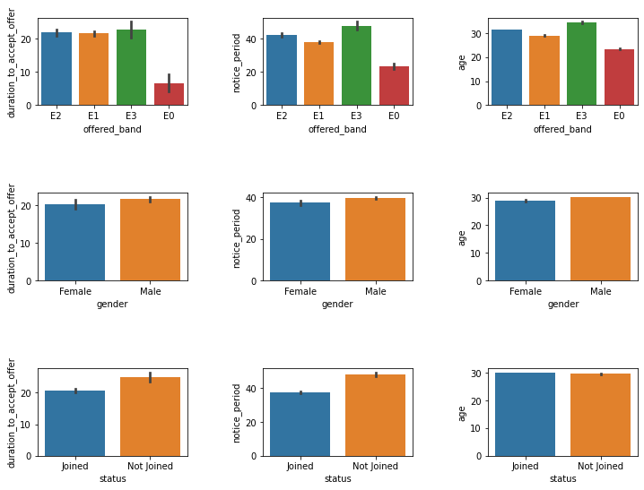

```python
numerical_features_set = ['duration_to_accept_offer','notice_period','age']
categorical_features_set = ['offered_band','gender','status']

xcnt=0
ycnt = 0
fig, axes = plt.subplots(3,3, figsize=(12,9))
fig.subplots_adjust(hspace = 1, wspace=.5)

for c in categorical_features_set:
    for n in numerical_features_set:
        bar_plot(c,n,xcnt,ycnt)
        ycnt = ycnt+1
    xcnt = xcnt+1
    ycnt=0
```

#### 3b. Visulaztion using seaborn

The details about seaborn package can be found at: https://seaborn.pydata.org/

```python
#sn.pairplot(filter_df, hue="status")
```

A strip plot can be drawn on its own, but it is also a good complement to a box or violin plot in cases where you want to show all observations along with some representation of the underlying distribution.

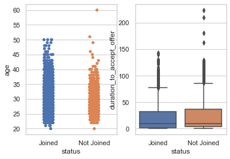

```python
sn.set(style="whitegrid", color_codes=True)
fig, (ax1, ax2) = plt.subplots(1,2)

sn.stripplot(x='status', y='age', data=filter_df, jitter=True, ax = ax1)
sn.boxplot(x='status', y='duration_to_accept_offer', data=filter_df, ax=ax2)
```

**violinplot()**, combines a boxplot with the kernel density estimation. This approach uses the kernel density estimate to provide a better description of the distribution of values. Additionally, the quartile and whikser values from the boxplot are shown inside the violin.

There are several options for the plot that is drawn on the interior of the violins, including ways to show each individual observation instead of the summary boxplot values:

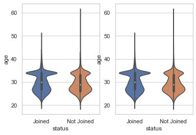

```python
fig, (ax1, ax2) = plt.subplots(1,2)
sn.violinplot(x='status', y='age', data=filter_df, ax=ax1)
sn.violinplot(x='status', y='age', data=filter_df, ax=ax2)
```

## Model Building:

### Dummy Variable coding

Remove the response variable from the dataset¶

```python
X_features = list(filter_df.columns)
X_features.remove('status')
X_features.remove('pecent_hike_expected_in_ctc')
X_features.remove('percent_hike_offered_in_ctc')
X_features.remove('candidate_relocate_actual')
```

```python
X_features
```

```
['doj_extended',
 'duration_to_accept_offer',
 'notice_period',
 'offered_band',
 'percent_difference_ctc',
 'joining_bonus',
 'gender',
 'candidate_source',
 'rex_in_yrs',
 'lob',
 'location',
 'age']
```

```python
encoded_X_df = pd.get_dummies( filter_df[X_features])
encoded_Y_df = pd.get_dummies( filter_df['status'], drop_first=False)
```

```python
pd.options.display.max_columns = None
encoded_X_df.info()
```

```
<class 'pandas.core.frame.DataFrame'>
Int64Index: 8995 entries, 0 to 8994
Data columns (total 36 columns):
 #   Column                              Non-Null Count  Dtype
---  ------                              --------------  -----
 0   duration_to_accept_offer            8995 non-null   int64
 1   notice_period                       8995 non-null   int64
 2   percent_difference_ctc              8995 non-null   float64
 3   rex_in_yrs                          8995 non-null   int64
 4   age                                 8995 non-null   int64
 5   doj_extended_No                     8995 non-null   uint8
 6   doj_extended_Yes                    8995 non-null   uint8
 7   offered_band_E0                     8995 non-null   uint8
 8   offered_band_E1                     8995 non-null   uint8
 9   offered_band_E2                     8995 non-null   uint8
```

[output cut: 28 more lines]

```python
Y = encoded_Y_df.filter(['Joined'], axis =1)
X = encoded_X_df
Y.info()
```

```
<class 'pandas.core.frame.DataFrame'>
Int64Index: 8995 entries, 0 to 8994
Data columns (total 1 columns):
 #   Column  Non-Null Count  Dtype
---  ------  --------------  -----
 0   Joined  8995 non-null   uint8
dtypes: uint8(1)
memory usage: 399.1 KB
```

### Train and test data split using Python

The train and test split can also be done using the **sklearn module**

```python
from sklearn.model_selection import train_test_split

X_train, X_test, y_train, y_test = train_test_split( X, Y, test_size = 0.2, random_state = 42)
```

## Model Building: Using the **sklearn**

```python
from sklearn import ensemble #linear_model, ensemble, neural_network, naive bayes, svm, tree
#dir(ensemble)
```

```python
"""
The “balanced” mode uses the values of y to automatically adjust weights
inversely proportional to class frequencies in the input data as
n_samples / (n_classes * np.bincount(y))
"""


rf_model = ensemble.RandomForestClassifier(bootstrap=True,
                                           criterion='gini',
                                           max_depth=4,
                                           max_features='auto',
                                           min_impurity_decrease=0.001,
                                           min_samples_leaf=30,
                                           min_samples_split=50,
                                           class_weight="balanced_subsample", #to remove class imbalance (balanced)
                                           n_estimators=500,
                                           oob_score=True,
                                           random_state=42,
                                           verbose=0,
                                           warm_start=False)

rf_model.fit(X_train,y_train)
#rf_model.fit(os_data_X,os_data_y)
```

```
'\nThe “balanced” mode uses the values of y to automatically adjust weights \ninversely proportional to class frequencies in the input data as \nn_samples / (n_classes * np.bincount(y))\n'
```

```
RandomForestClassifier(class_weight='balanced_subsample', max_depth=4,
                       min_impurity_decrease=0.001, min_samples_leaf=30,
                       min_samples_split=50, n_estimators=500, oob_score=True,
                       random_state=42)
```

The problem with above approach is to understand which combination is the best. Should we have made a tree with `max_depth` as 4 and `min_sample_leaf` as 30 or should there have been other combination. Searching the grid for the best combination can be taken care of by `RandomizedSearchCV` method of `model_selection`

### Random Search with cross validation

To use RandomizedSearchCV, create a parameter grid from where sample will be picked during model building:

```python
# Number of trees in random forest
n_estimators = [100,120,150,200, 240, 400]

# Maximum number of levels in tree
max_depth = [2,3,4,5,66,7,8,9]
max_depth.append(None)

# Number of features to consider at every split
max_features = ['auto', 'log2']

# Minimum number of samples required to split a node
min_samples_split = [50, 75, 100]

# Minimum number of samples required at each leaf node
min_samples_leaf = [30, 35, 40]

# Method of selecting samples for training each tree
bootstrap = [True, False]

# How to remove the class imbalance
class_weight=['balanced_subsample','balanced']

# Create the random grid
random_grid = {'n_estimators': n_estimators,
               'max_depth': max_depth,
               'max_features': max_features,
               'min_samples_split': min_samples_split,
               'min_samples_leaf': min_samples_leaf,
               'bootstrap': bootstrap,
               'class_weight': class_weight}
random_grid
```

```
{'n_estimators': [100, 120, 150, 200, 240, 400],
 'max_depth': [2, 3, 4, 5, 66, 7, 8, 9, None],
 'max_features': ['auto', 'log2'],
 'min_samples_split': [50, 75, 100],
 'min_samples_leaf': [30, 35, 40],
 'bootstrap': [True, False],
 'class_weight': ['balanced_subsample', 'balanced']}
```

### Model with Random Search

Refer here to understand the details of parallel processing: https://stackoverflow.com/questions/32673579/scikit-learn-general-question-about-parallel-computing

```python
from sklearn.model_selection import RandomizedSearchCV
RandomizedSearchCV?
```

To report the performance on the selected KPI use `sklearn.metrics.SCORERS.keys()` to get the list of all the metrics and pass the relevant one in `RandomizedSearchCV` or `GridSearchCV`

```python
from sklearn.metrics import SCORERS

SCORERS.keys()
```

```
dict_keys(['explained_variance', 'r2', 'max_error', 'neg_median_absolute_error', 'neg_mean_absolute_error', 'neg_mean_squared_error', 'neg_mean_squared_log_error', 'neg_root_mean_squared_error', 'neg_mean_poisson_deviance', 'neg_mean_gamma_deviance', 'accuracy', 'roc_auc', 'roc_auc_ovr', 'roc_auc_ov…
```

```python
# Use the random grid to search for best hyperparameters
from sklearn.model_selection import RandomizedSearchCV

rf_model = ensemble.RandomForestClassifier()

# Random search of parameters, using 3 fold cross validation,
rf_best_model = RandomizedSearchCV(estimator = rf_model,
                               param_distributions = random_grid, scoring = "roc_auc",
                               n_iter = 100, cv = 3, verbose=2, random_state=42, n_jobs = -2, pre_dispatch =2)
# Fit the random search model
rf_best_model
rf_best_model.fit(X_train, y_train)
```

```
RandomizedSearchCV(cv=3, estimator=RandomForestClassifier(), n_iter=100,
                   n_jobs=-2,
                   param_distributions={'bootstrap': [True, False],
                                        'class_weight': ['balanced_subsample',
                                                         'balanced'],
                                        'max_depth': [2, 3, 4, 5, 66, 7, 8, 9,
                                                      None],
                                        'max_features': ['auto', 'log2'],
                                        'min_samples_leaf': [30, 35, 40],
                                        'min_samples_split': [50, 75, 100],
                                        'n_estimators': [100, 120, 150, 200,
                                                         240, 400]},
                   pre_dispatch=2, random_state=42, scoring='roc_auc',
                   verbose=2)
```

```
Fitting 3 folds for each of 100 candidates, totalling 300 fits
```

```
[Parallel(n_jobs=-2)]: Using backend LokyBackend with 7 concurrent workers.
[Parallel(n_jobs=-2)]: Done  39 tasks      | elapsed:   20.7s
[Parallel(n_jobs=-2)]: Done 160 tasks      | elapsed:   52.5s
[Parallel(n_jobs=-2)]: Done 300 out of 300 | elapsed:  1.5min finished
```

```
RandomizedSearchCV(cv=3, estimator=RandomForestClassifier(), n_iter=100,
                   n_jobs=-2,
                   param_distributions={'bootstrap': [True, False],
                                        'class_weight': ['balanced_subsample',
                                                         'balanced'],
                                        'max_depth': [2, 3, 4, 5, 66, 7, 8, 9,
                                                      None],
                                        'max_features': ['auto', 'log2'],
                                        'min_samples_leaf': [30, 35, 40],
                                        'min_samples_split': [50, 75, 100],
                                        'n_estimators': [100, 120, 150, 200,
                                                         240, 400]},
                   pre_dispatch=2, random_state=42, scoring='roc_auc',
                   verbose=2)
```

### Report the parameter

The best model has the following parameter selected from the random search grid

```python
rf_best_model.best_params_

rf_best_model.best_estimator_

#cv_result = pd.DataFrame(rf_best_model.cv_results_)
#cv_result

rf_best_model.best_score_

#rf__best_model.best_index_
```

```
{'n_estimators': 100,
 'min_samples_split': 75,
 'min_samples_leaf': 30,
 'max_features': 'log2',
 'max_depth': None,
 'class_weight': 'balanced',
 'bootstrap': False}
```

```
RandomForestClassifier(bootstrap=False, class_weight='balanced',
                       max_features='log2', min_samples_leaf=30,
                       min_samples_split=75)
```

```
0.7160642818359003
```

### Grid Search with Cross Validation

Random search allows to narrow down the range for each hyperparameter. Thus we know where to concentrate the search, to fine tune the model further.

`GridSearchCV`, is a method that instead of sampling randomly from a distribution, evaluates all combinations which are defined. The grid search can be called `from sklearn.model_selection import GridSearchCV`

You are encouraged to fine tune the model further using Grid Search

## Model Evaluation

### 1. The prediction on train data.

To predict the outcome on the **train set**

> - Use **predict** function of the model object

```python
# Make predictions using the testing set
#pd.options.display.max_rows = None

predict_class_train_df = pd.DataFrame(rf_best_model.predict(X_train))
predict_class_train_df.head()

predict_porb_train_df = pd.DataFrame(rf_best_model.predict_proba(X_train))
predict_porb_train_df.iloc[:,:].head()
```

|  | 0 |
| --- | --- |
| 0 | 1 |
| 1 | 1 |
| 2 | 0 |
| 3 | 0 |
| 4 | 0 |

|  | 0 | 1 |
| --- | --- | --- |
| 0 | 0.329356 | 0.670644 |
| 1 | 0.469195 | 0.530805 |
| 2 | 0.602255 | 0.397745 |
| 3 | 0.538259 | 0.461741 |
| 4 | 0.600589 | 0.399411 |

The above output clearly shows that the predcited class is the one for which the calculated probability is more compared to the calculated probability of the other class.

### 2. The prediction on test data.

The prediction can be carried out by **defining functions** as well. Below is one such instance wherein a function is defined and is used for prediction

```python
def get_predictions ( test_class, model, test_data ):
    predicted_df = pd.DataFrame(model.predict_proba(test_data))
    y_pred_df = pd.concat([test_class.reset_index(drop=True), predicted_df.iloc[:,1:]], axis =1)
    return y_pred_df
```

Giving label to the Y column of the test set by using the dictionary data type in python. This is being done for the model which was built using dummy variable coding. It will be used to generate confusion matrix at a later time

```python
test_series = y_test
train_series = y_train

status_dict = {1:"Joined", 0:"Not Joined"}
class_test_df = test_series.replace(dict(Joined=status_dict))
class_test_df.rename({'Joined': 'status'}, axis='columns', inplace=True )

class_train_df = train_series.replace(dict(Joined=status_dict))
class_train_df.rename({'Joined': 'status'}, axis='columns', inplace=True )

#class_test_df.info()
#class_train_df.info()
```

```python
predict_test_df = pd.DataFrame(get_predictions(class_test_df.status, rf_best_model, X_test))
predict_test_df.rename(columns = {1:'predicted_prob'}, inplace=True)
predict_test_df.head()
```

|  | status | predicted_prob |
| --- | --- | --- |
| 0 | Joined | 0.873897 |
| 1 | Joined | 0.505087 |
| 2 | Joined | 0.723944 |
| 3 | Joined | 0.422427 |
| 4 | Joined | 0.670895 |

```python
predict_test_df['predicted'] = predict_test_df.predicted_prob.map(lambda x: 'Joined' if x > 0.5 else 'Not Joined')
predict_test_df[0:10]
```

|  | status | predicted_prob | predicted |
| --- | --- | --- | --- |
| 0 | Joined | 0.873897 | Joined |
| 1 | Joined | 0.505087 | Joined |
| 2 | Joined | 0.723944 | Joined |
| 3 | Joined | 0.422427 | Not Joined |
| 4 | Joined | 0.670895 | Joined |
| 5 | Joined | 0.715118 | Joined |
| 6 | Not Joined | 0.399266 | Not Joined |
| 7 | Not Joined | 0.542923 | Joined |
| 8 | Not Joined | 0.770241 | Joined |
| 9 | Joined | 0.515672 | Joined |

### 3. Confusion Matrix

We will built classification matrix using the **metrics** method from **sklearn** package. We will also write a custom function to build a classification matrix and use it for reporting the performance measures.

To understand the concept of micro average and macro average:

https://datascience.stackexchange.com/questions/15989/micro-average-vs-macro-average-performance-in-a-multiclass-classification-settin

#### 3a. Confusion Matrix using sklearn

```python
from sklearn import metrics
from sklearn.metrics import confusion_matrix
from sklearn.metrics import classification_report
```

```python
print("The model with dummy variable coding output: ")
confusion_matrix(class_test_df.status, predict_test_df.predicted)
lg_reg_report = (classification_report(class_test_df, predict_test_df.predicted))
print(lg_reg_report)
```

```
The model with dummy variable coding output:
```

```
array([[1034,  425],
       [ 146,  194]])
```

```
              precision    recall  f1-score   support

      Joined       0.88      0.71      0.78      1459
  Not Joined       0.31      0.57      0.40       340

    accuracy                           0.68      1799
   macro avg       0.59      0.64      0.59      1799
weighted avg       0.77      0.68      0.71      1799
```

#### 3b Confusion Matrix using generic function

```python
def draw_cm( actual, predicted ):
    plt.figure(figsize=(9,9))
    cm = metrics.confusion_matrix( actual, predicted )
    sn.heatmap(cm, annot=True,  fmt='.0f', xticklabels = ["Joined", "Not Joined"] ,
               yticklabels = ["Joined", "Not Joined"],cmap = 'Blues_r')
    plt.ylabel('Actual')
    plt.xlabel('Predicted')
    plt.title('Classification Matrix Plot', size = 15);
    plt.show()
```

The classification matrix plot as reported with dummy variable coding is:

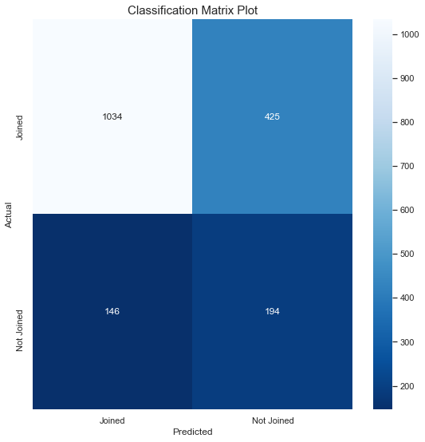

```python
draw_cm( predict_test_df.status, predict_test_df.predicted )
```

### 4. Performance Measure on the test set

```python
def measure_performance (clasf_matrix):
    measure = pd.DataFrame({
                        'sensitivity': [round(clasf_matrix[0,0]/(clasf_matrix[0,0]+clasf_matrix[0,1]),2)],
                        'specificity': [round(clasf_matrix[1,1]/(clasf_matrix[1,0]+clasf_matrix[1,1]),2)],
                        'recall': [round(clasf_matrix[0,0]/(clasf_matrix[0,0]+clasf_matrix[0,1]),2)],
                        'precision': [round(clasf_matrix[0,0]/(clasf_matrix[0,0]+clasf_matrix[1,0]),2)],
                        'overall_acc': [round((clasf_matrix[0,0]+clasf_matrix[1,1])/
                                              (clasf_matrix[0,0]+clasf_matrix[0,1]+clasf_matrix[1,0]+clasf_matrix[1,1]),2)]
                       })
    return measure
```

```python
cm = metrics.confusion_matrix(predict_test_df.status, predict_test_df.predicted)

lg_reg_metrics_df = pd.DataFrame(measure_performance(cm))
lg_reg_metrics_df

print( 'Total Accuracy sklearn: ',np.round( metrics.accuracy_score( class_test_df.status, predict_test_df.predicted ), 2 ))
```

|  | sensitivity | specificity | recall | precision | overall_acc |
| --- | --- | --- | --- | --- | --- |
| 0 | 0.71 | 0.57 | 0.71 | 0.88 | 0.68 |

```
Total Accuracy sklearn:  0.68
```